# Unidad 2.2

# Unidad II. Regresiones y reducción de dimensionalidad.

## Regresión Lineal Múltiple por el método de los Mínimos Cuadrados.

- Examen de los residuos. Prueba de normalidad de los residuales.
- Prueba de homogeneidad de varianza.
- Mínimos Cuadrados Ponderados.
- Observaciones extremas.
- Búsqueda de la mejor ecuación de regresión. Stepwise regression

### Regresión Lineal Múltiple

Vamos a simular un modelo lineal completo.

```r
# Simulación de las variables aleatorias.
nvars <- 2
nvalues <- 10
variables <- replicate(nvars, {runif(nvalues)})
```

```r
# Simulación de la intersección
alpha <- runif(1)
alpha
```

```
## [1] 0.4617156
```

```r
# Simulación de la intersección
betas <- runif(nvars)
betas
```

```
## [1] 0.5505094 0.4786325
```

```r
errors <- 0.05 * runif(nvalues)
```

```r
Y <- alpha + variables %*% betas + errors
Y
```

```
##            [,1]
##  [1,] 1.4133744
##  [2,] 1.1706037
##  [3,] 0.9433037
##  [4,] 1.3804622
##  [5,] 0.8470274
##  [6,] 1.4107558
##  [7,] 0.8315154
##  [8,] 0.6469486
##  [9,] 0.5563695
## [10,] 0.9033350
```

En R, la función *lm* permite hacer regresiones de cuadrados mínimos para modelos lineales.

```r
my_model <- lm(Y ~ variables[,1] + variables[,2])
my_model
```

```
##
## Call:
## lm(formula = Y ~ variables[, 1] + variables[, 2])
##
## Coefficients:
##    (Intercept)  variables[, 1]  variables[, 2]
##         0.4893          0.5493          0.4731
```

```r
coefficients(my_model)
```

```
##    (Intercept) variables[, 1] variables[, 2]
##      0.4892868      0.5493330      0.4730517
```

```r
residuals(my_model)
```

```
##             1             2             3             4             5
## -0.0107291007 -0.0003454217 -0.0019553409 -0.0034339733 -0.0059261640
##             6             7             8             9            10
##  0.0165170998 -0.0192469520 -0.0026743803  0.0062926028  0.0215016303
```

```r
summary(my_model)
```

```
##
## Call:
## lm(formula = Y ~ variables[, 1] + variables[, 2])
##
## Residuals:
##       Min        1Q    Median        3Q       Max
## -0.019247 -0.005303 -0.002315  0.004633  0.021502
##
## Coefficients:
##                Estimate Std. Error t value Pr(>|t|)
## (Intercept)    0.489287   0.008779   55.73 1.57e-10 ***
## variables[, 1] 0.549333   0.018904   29.06 1.47e-08 ***
## variables[, 2] 0.473052   0.019242   24.59 4.69e-08 ***
## ---
## Signif. codes:  0 '***' 0.001 '**' 0.01 '*' 0.05 '.' 0.1 ' ' 1
##
## Residual standard error: 0.01372 on 7 degrees of freedom
## Multiple R-squared:  0.9985, Adjusted R-squared:  0.9981
## F-statistic:  2381 on 2 and 7 DF,  p-value: 1.211e-10
```

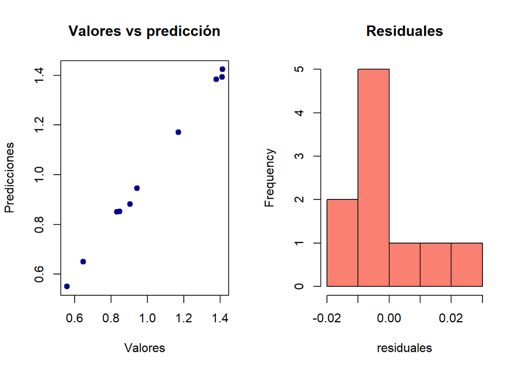

```r
par(mfrow=c(1,2))
plot(
  x=Y,
  y=my_model$fitted.values,
  main="Valores vs predicción",
  xlab="Valores",
  ylab="Predicciones",
  col="darkblue",
  pch=19
)

hist(
  my_model$residuals,
  main="Residuales",
  xlab="residuales",
  col="salmon"
)
```

```r
glm(
  Y ~ variables[,1] + variables[,2]
)
```

```
##
## Call:  glm(formula = Y ~ variables[, 1] + variables[, 2])
##
## Coefficients:
##    (Intercept)  variables[, 1]  variables[, 2]
##         0.4893          0.5493          0.4731
##
## Degrees of Freedom: 9 Total (i.e. Null);  7 Residual
## Null Deviance:       0.8982
## Residual Deviance: 0.001318  AIC: -52.96
```

#### Coeficientes de determinación

Es el valor $R^2$ de la regresión. Es la proporción de la varianza de la variables de respuesta que puede ser predicha a partir de las variables explicativas.

El valor de $R^2$ varía entre 0 y 1. Cuanto mayor es, menos incerteza se tiene de los valores reales a partir del modelo. Es decir, mejor es la predicción.

$$\text{sum of squares of the data} = SS_{data} = \sum_i{(y_i-\bar{y})^2} \\
\text{sum of squares of prediction} = SS_{pred} = \sum_i{(fit(y_i)-\bar{y})^2} \\
R^2 = \frac{SS_{pred}}{SS_{data}}$$

```r
# Calculo la media de los valores observados
mean_y <- mean(Y)

# Calculo la suma de cuadrados de las observaciones
ss_data <- sum((Y-mean_y)^2)

# Calculo la suma de cuadrados de las predicciones
ss_pred <- sum((my_model$fitted.values-mean_y)^2)

# Calculo el coeficiente de determinación
R2a <- ss_pred/ss_data
R2a
```

```
## [1] 0.9985323
```

```r
# Extraigo el coeficiente de determinación del modelo.
R2b <- summary(my_model)$r.squared
R2b
```

```
## [1] 0.9985323
```

Veamos como cambia el $R^2$ con el error del modelo.

```r
nvars <- 2
nvalues <- 50
variables <- replicate(nvars, {runif(nvalues)})

alpha <- runif(1)
alpha
```

```
## [1] 0.4053067
```

```r
betas <- runif(nvars)
betas
```

```
## [1] 0.8175160 0.5202013
```

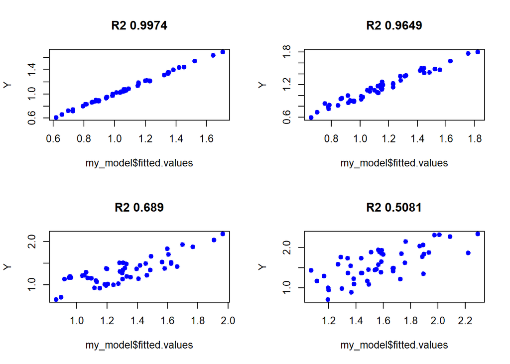

```r
par(mfrow=c(2,2))
for (i in c(0.05, 0.2, 0.5, 1)) {
  errors <- i * runif(nvalues)
  Y <- alpha + variables %*% betas + errors
  my_model <- lm(Y ~ variables)
  plot(
    Y ~ my_model$fitted.values,
    main=paste("R2", round(summary(my_model)$r.squared, 4)),
    pch=19,
    col="blue"
  )
}
```

#### Residuos

Los residuos es la diferencia entre los valores observados y los valores predichos.

```r
residuos = Y - fitted.values(my_model)

res <- data.frame(
  "a mano"= residuos,
  "del modelo"= my_model$residuals
)
head(res)
```

```
##        a.mano  del.modelo
## 1  0.34187897  0.34187897
## 2 -0.07464336 -0.07464336
## 3 -0.09177221 -0.09177221
## 4 -0.26067932 -0.26067932
## 5 -0.07952461 -0.07952461
## 6  0.18964175  0.18964175
```

#### Supuestos

- **Linealidad**: Si no se cumple se comete un error de especificación, dado que el modelo será incorrecto. En el caso de una o dos variables independientes, ayuda observar un gráfico de dispersión en busca de una tendencia lineal (línea, plano).
- **Independencia de los residuos**: Los residuos no deben estar correlacionados (deben ser una variable aleatoria). El *estadístico de Durbin-Watson* puede ayudar en la detección de autocorrelaciones.
- **Homocedasticidad**: Igualdad de varianza para cada valor o grupo de valores de la/s variable/s independiente/s
- **Normalidad**: Para cada valor o grupo de valores de la/s variable/s independiente/s los residuos se distribuyen de manera normal con $\mu = 0$
- **No-colinealidad**: Las variables independientes no pueden ser combinaciones lineales unas de otras, no debe haber correlación entre ellas.

### Mínimos Cuadrados Ponderados.

En el caso de no cumplirse con la homocedacia, es posible darle a cada observación un peso inversamente proporcional a la varianza para ese valor o grupo de valores de la/s variable/s independiente/s en una regresion por minimos cuadrados ponderados.

Lo óptimo es conocer de antemano cual es la varianza de cada medición. Por ejemplo si medimos cada dato con una herramienta diferente y conocemos su error. Sino existen maneras de determinar los posibles valores de la varianza (o de un estimador robusto correlacionado con ésta) con respecto a las variables independientes.

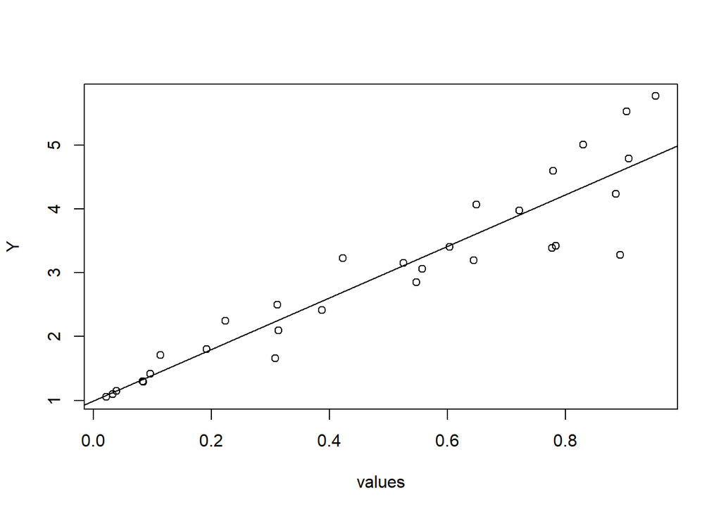

```r
nobs <- 30
nvars <- 1
values <- replicate(nvars, {runif(nobs)})
beta <- 4
alpha <- 1

# Acá estamos introduciendo la
# heterocedasticidad
errors <- rnorm(nobs, 0, 1) * values

Y <- alpha + values*beta + errors

my_model <- lm(
  formula = Y ~ values
)

plot(values, Y)
abline(my_model)
```

```r
summary(my_model)
```

```
##
## Call:
## lm(formula = Y ~ values)
##
## Residuals:
##      Min       1Q   Median       3Q      Max
## -1.31810 -0.17567 -0.01147  0.25596  0.92632
##
## Coefficients:
##             Estimate Std. Error t value Pr(>|t|)
## (Intercept)   0.9900     0.1657   5.977 1.95e-06 ***
## values        4.0420     0.2869  14.087 3.10e-14 ***
## ---
## Signif. codes:  0 '***' 0.001 '**' 0.01 '*' 0.05 '.' 0.1 ' ' 1
##
## Residual standard error: 0.4886 on 28 degrees of freedom
## Multiple R-squared:  0.8763, Adjusted R-squared:  0.8719
## F-statistic: 198.4 on 1 and 28 DF,  p-value: 3.104e-14
```

```r
beta
```

```
## [1] 4
```

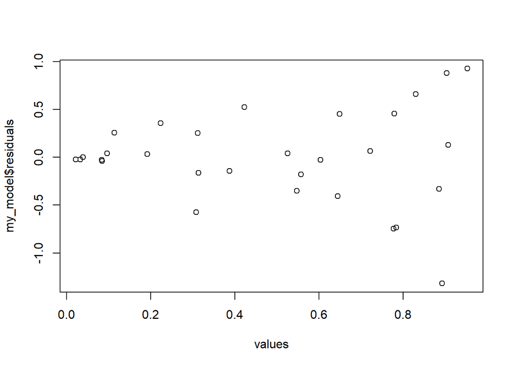

```r
plot(
  values,
  my_model$residuals)
```

Vamos a modelar los residuos. Primero vamos a estimar la varianza localmente usando bins.

```r
my_bins <- as.data.frame(cbind(
  start=seq(0,0.9,0.05),
  midpoint=seq(0,0.9,0.05)+0.05,
  end=seq(0,0.9,0.05)+0.1
))

mad_bins <- apply(
  my_bins,
  MARGIN = 1,
  FUN = function(x) {
    r <- residuals(my_model)
    r <- r[x["start"]<values & values<=x["end"]]
    mad(r)
  }
)

my_bins <- cbind(
  my_bins,
  mad=mad_bins
)
```

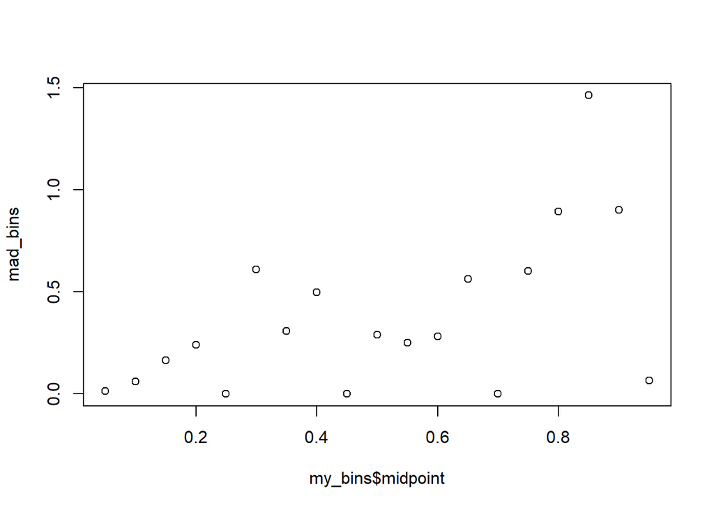

```r
plot(
  x=my_bins$midpoint,
  y=mad_bins
)
```

Ahora, generamos un modelo lineal, con el resultado de los bins.

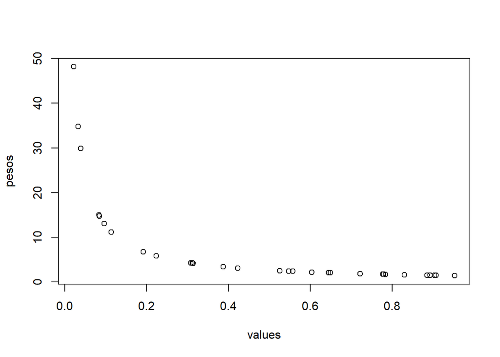

```r
res_mad_model <- lm(
  mad ~ midpoint,
  data=my_bins
)

predicted_mad <- predict.lm(
  res_mad_model,
  data.frame(
    midpoint=values
    )
)

pesos <- 1 / predicted_mad

plot(
  x=values,
  y=pesos
)
```

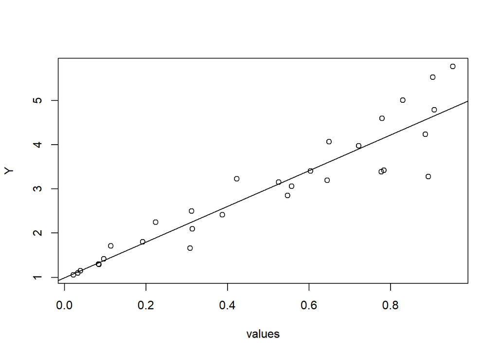

```r
weighted_model <- lm(
  formula = Y ~ values,
  weights = pesos
)
plot(values, Y)
abline(my_model)
```

```r
weighted_model
```

```
##
## Call:
## lm(formula = Y ~ values, weights = pesos)
##
## Coefficients:
## (Intercept)       values
##      0.9933       4.0352
```

En general es preferible usar pesos cuando éstos se conocen de antemano. Por ejemplo si se conoce el error experimental de los instrumentos, B factors o resolución en estructuras cristalográficas, etc. Tratar de encontrar pesos puede ser complicado.

### Ridge Regression

Esta regresión es mucho más robusta a la presencia de variables explicativas correlacionadas (colineales).

```r
# En este ejemplo, vamos a modelar la
# variable GNP.deflator como respuesta al
# resto de las variables aleatorias.
head(longley)
```

```
##      GNP.deflator     GNP Unemployed Armed.Forces Population Year Employed
## 1947         83.0 234.289      235.6        159.0    107.608 1947   60.323
## 1948         88.5 259.426      232.5        145.6    108.632 1948   61.122
## 1949         88.2 258.054      368.2        161.6    109.773 1949   60.171
## 1950         89.5 284.599      335.1        165.0    110.929 1950   61.187
## 1951         96.2 328.975      209.9        309.9    112.075 1951   63.221
## 1952         98.1 346.999      193.2        359.4    113.270 1952   63.639
```

#### Buscando colinearidad

##### Calculemos las correlaciones.

La correlación y la covarianza son medidas de variación conjunta entre dos variables aleatorias.

La covarianza es una medida que depende de las unidades y escalas de las variables aleatorias, por lo que no siempre es útil. La correlación es una medida sin unidades que varía entre -1 y 1. Lo cual la hace mucho más fácil de trabajar e interpretar.

$$cov(X,Y) =\frac{\sum(x_i-\bar{x})(y_i-\bar{y})}{n-1} \\
cor(X,Y) = cov(X,Y)/(\sigma_x \sigma_y)$$

```r
a <- c(1,3,5)
b <- c(3,4,7)
cov(a,b)
```

```
## [1] 4
```

```r
ad <- a - mean(a)
bd <- b - mean(b)
cv <- sum(ad*bd) / 2

cor(a,b)
```

```
## [1] 0.9607689
```

```r
cr <- cv / (sd(a)*(sd(b)))
cr
```

```
## [1] 0.9607689
```

```r
cor(longley[-1])
```

```
##                    GNP Unemployed Armed.Forces Population      Year  Employed
## GNP          1.0000000  0.6042609    0.4464368  0.9910901 0.9952735 0.9835516
## Unemployed   0.6042609  1.0000000   -0.1774206  0.6865515 0.6682566 0.5024981
## Armed.Forces 0.4464368 -0.1774206    1.0000000  0.3644163 0.4172451 0.4573074
## Population   0.9910901  0.6865515    0.3644163  1.0000000 0.9939528 0.9603906
## Year         0.9952735  0.6682566    0.4172451  0.9939528 1.0000000 0.9713295
## Employed     0.9835516  0.5024981    0.4573074  0.9603906 0.9713295 1.0000000
```

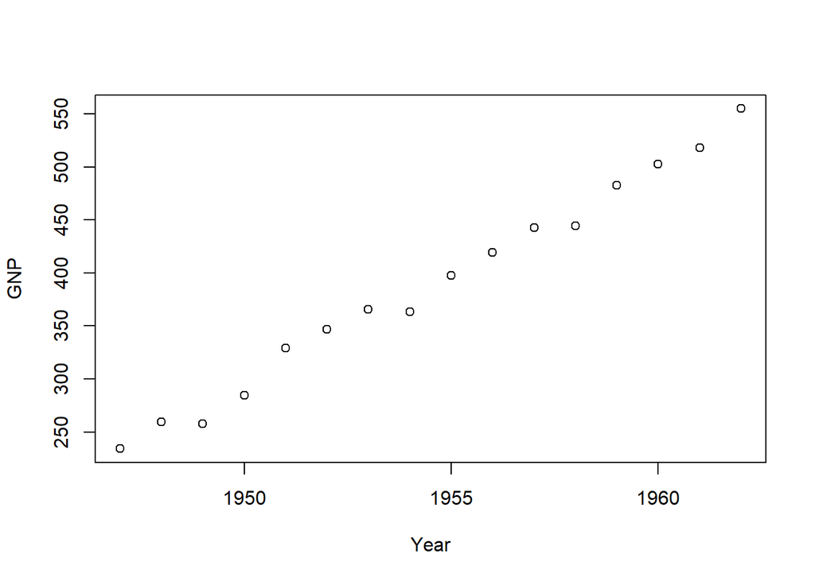

```r
plot(GNP~Year, longley)
```

##### Calculamos el Variance Increasing Factor

El VIF es una medida de la colinearidad en un sistema de regresión multiple. Es una medida del incremento de la varianza en el modelo completo vs al modelo con una sola varible.

Se calcular un valor de VIF para cada variable aleatoria del modelo.

```r
# Calculo un modelo donde la variable a evaluar
# Year en este caso es respuesta de las demás
# variables aleatorias del modelo.
# La variable de respuesta original se elimina.
my_vif_model <- lm(
  Year ~ .,
  data=longley[-1]
)

# Calculo el coeficiente de determinación
r2 <- summary(my_vif_model)$r.squared

# Calculo el vif para year
vif_year <- 1/(1-r2)
vif_year
```

```
## [1] 2065.734
```

```r
# Calculamos el VIF para todas las variables
# library(car)
vif(
  lm(
    GNP.deflator ~ .,
    data=longley
  )
)
```

```
##          GNP   Unemployed Armed.Forces   Population         Year     Employed
##   1214.57215     83.95865     12.15639    230.91221   2065.73394    220.41968
```

Separamos los datos en un conjunto de entrenamiento y un conjunto de prueba

```r
training_size <- as.integer(nrow(longley) * 0.6)
test_size <- nrow(longley) - training_size

training_rows <- sample(
    x=nrow(longley),
    size=training_size
)

training_set <- longley[training_rows, ]
test_set <- longley[-training_rows, ]
```

Calculemos un modelo lineal en el grupo de entrenamiento.

```r
my_model <- lm(
  GNP.deflator ~ .,
  data=training_set)

summary(my_model)
```

```
##
## Call:
## lm(formula = GNP.deflator ~ ., data = training_set)
##
## Residuals:
##     1951     1953     1960     1948     1947     1954     1955     1949
##  0.03659 -0.08589  0.18157 -0.03425  0.12601  0.16302 -0.15847 -0.11413
##     1961
## -0.11445
##
## Coefficients:
##                Estimate Std. Error t value Pr(>|t|)
## (Intercept)  -1.147e+04  1.990e+03  -5.766   0.0288 *
## GNP           2.628e-01  2.712e-02   9.691   0.0105 *
## Unemployed   -9.798e-02  1.432e-02  -6.841   0.0207 *
## Armed.Forces -5.692e-02  7.606e-03  -7.484   0.0174 *
## Population   -7.391e-01  2.466e-01  -2.997   0.0956 .
## Year          6.253e+00  1.052e+00   5.945   0.0271 *
## Employed     -9.397e+00  1.004e+00  -9.359   0.0112 *
## ---
## Signif. codes:  0 '***' 0.001 '**' 0.01 '*' 0.05 '.' 0.1 ' ' 1
##
## Residual standard error: 0.2613 on 2 degrees of freedom
## Multiple R-squared:  0.9999, Adjusted R-squared:  0.9995
## F-statistic:  2450 on 6 and 2 DF,  p-value: 0.0004081
```

Usamos el modelo para predecir las respuestas del modelo en el conjunto de datos de prueba.

```r
predicted <- predict (
  my_model,
  test_set
)
res_mean <- mean(abs(predicted - test_set$GNP.deflator))
res_mean
```

```
## [1] 4.253084
```

Ahora probamos el *ridge model*.

```r
my_ridged_model <- linearRidge(
  GNP.deflator ~ .,
  data=training_set
)
summary(my_ridged_model)
```

```
##
## Call:
## linearRidge(formula = GNP.deflator ~ ., data = training_set)
##
##
## Coefficients:
##                Estimate Scaled estimate Std. Error (scaled) t value (scaled)
## (Intercept)  -9.840e+02              NA                  NA               NA
## GNP           3.700e-02       1.073e+01           1.745e+00            6.146
## Unemployed    4.168e-03       1.169e+00           2.006e+00            0.583
## Armed.Forces  8.368e-03       1.903e+00           1.816e+00            1.048
## Population    3.059e-01       6.181e+00           2.565e+00            2.409
## Year          5.091e-01       7.179e+00           1.284e+00            5.593
## Employed      5.629e-01       5.654e+00           1.932e+00            2.926
##              Pr(>|t|)
## (Intercept)        NA
## GNP          7.96e-10 ***
## Unemployed    0.56022
## Armed.Forces  0.29451
## Population    0.01598 *
## Year         2.23e-08 ***
## Employed      0.00344 **
## ---
## Signif. codes:  0 '***' 0.001 '**' 0.01 '*' 0.05 '.' 0.1 ' ' 1
##
## Ridge parameter: 0.02098055, chosen automatically, computed using 2 PCs
##
## Degrees of freedom: model 3.053 , variance 2.814 , residual 3.292
```

```r
predicted <- predict (
  my_ridged_model,
  test_set
)
res_mean <- mean(abs(predicted - test_set$GNP.deflator))
res_mean
```

```
## [1] 1.41484
```

# Crear un modelo recalibrado

En el nuevo modelo eliminas las varibles con el mayor VIF: “Year”, “Population” y “GNP”

```r
trimmed_training_set <- training_set[,
  !colnames(training_set) %in% c("Year", "Population", "GNP")
  ]
my_trimmed_model <- lm(
  GNP.deflator ~ .,
  data=trimmed_training_set
)
summary(my_trimmed_model)
```

```
##
## Call:
## lm(formula = GNP.deflator ~ ., data = trimmed_training_set)
##
## Residuals:
##    1951    1953    1960    1948    1947    1954    1955    1949    1961
##  1.7630 -0.1075  0.3831  1.6606 -2.1402  0.1699 -2.1399  0.1716  0.2394
##
## Coefficients:
##                Estimate Std. Error t value Pr(>|t|)
## (Intercept)  -75.020305  14.664849  -5.116 0.003721 **
## Unemployed     0.024321   0.008625   2.820 0.037117 *
## Armed.Forces   0.017470   0.010270   1.701 0.149678
## Employed       2.514011   0.278665   9.022 0.000279 ***
## ---
## Signif. codes:  0 '***' 0.001 '**' 0.01 '*' 0.05 '.' 0.1 ' ' 1
##
## Residual standard error: 1.749 on 5 degrees of freedom
## Multiple R-squared:  0.9848, Adjusted R-squared:  0.9756
## F-statistic: 107.7 on 3 and 5 DF,  p-value: 5.812e-05
```

```r
predicted <- predict (
  my_trimmed_model,
  test_set
)
res_mean <- mean(abs(predicted - test_set$GNP.deflator))
res_mean
```

```
## [1] 1.337883
```

```r
predicted
```

```
##      1950      1952      1956      1957      1958      1959      1962
##  89.83703  95.94647 107.42757 108.38612 108.18564 111.31110 117.02993
```

```r
test_set$GNP.deflator
```

```
## [1]  89.5  98.1 104.6 108.4 110.8 112.6 116.9
```